# Solutions to the exercises during BLR-R Ladies | WAQSA Workshop

```r
library(tidyverse)
```

#### Exercise

Modify the code below to make the points larger triangles and slightly transparent. See `?geom_point` for more information on the point layer.

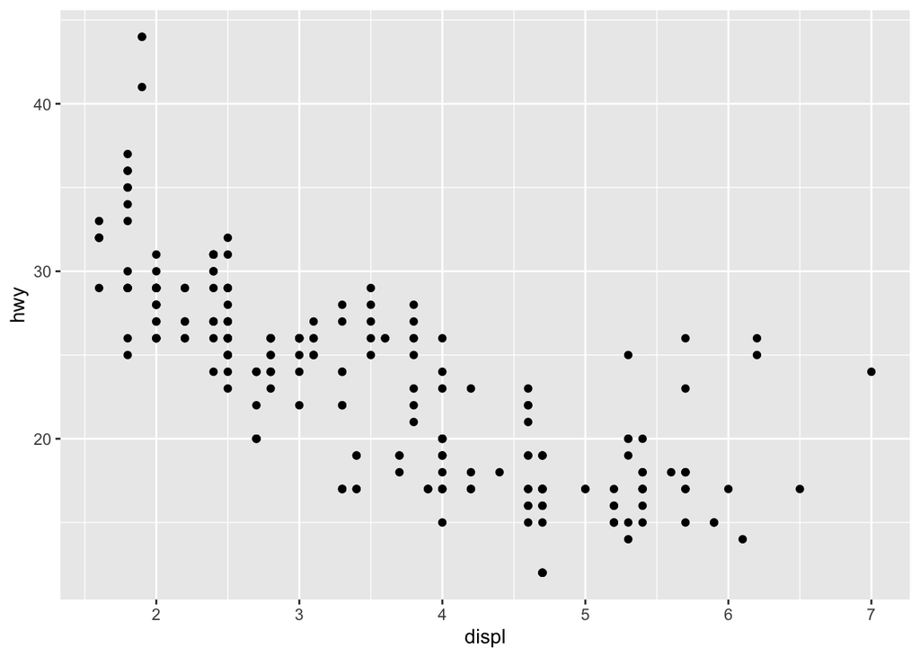

```r
ggplot(mpg) +
  geom_point(aes(x = displ, y = hwy))
```

Solution:

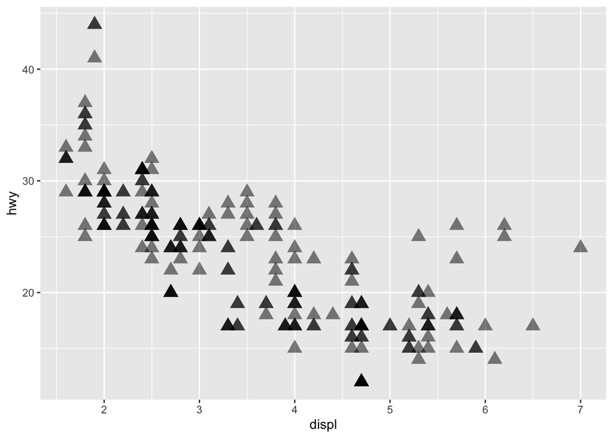

```r
ggplot(mpg) +
  geom_point(aes(x = displ, y = hwy), shape="triangle", size=4, alpha=0.5)
```

Using the `mpg` dataset draw a line chart, a boxplot, and a histogram

Solution:

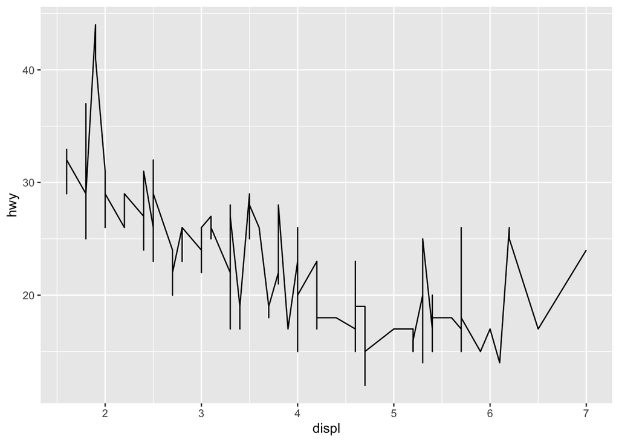

```r
ggplot(data=mpg)+
  geom_line(aes(x=displ, y=hwy))
```

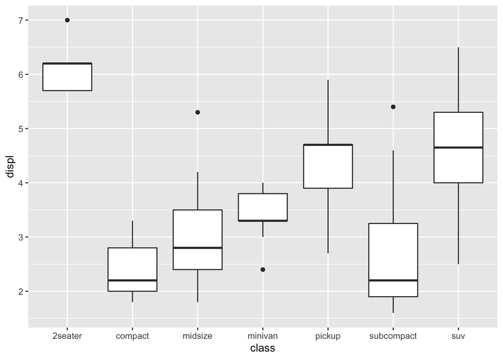

```r
ggplot(data=mpg)+
  geom_boxplot(aes(x=class, y=displ))
```

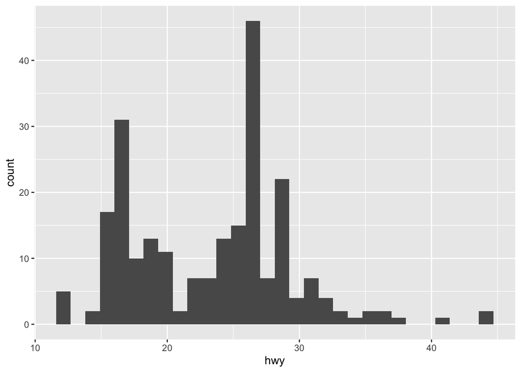

```r
ggplot(data=mpg)+
  geom_histogram(aes(x=hwy))
```

### Stat

Look at the documentation for geom_bar using `?geom_bar`

We learnt that `geom_*()` and `stat_*()` are interchangeable. Can you look at `?geom_bar()` and figure out which stat it uses as default. Modify the code below to use that stat directly instead

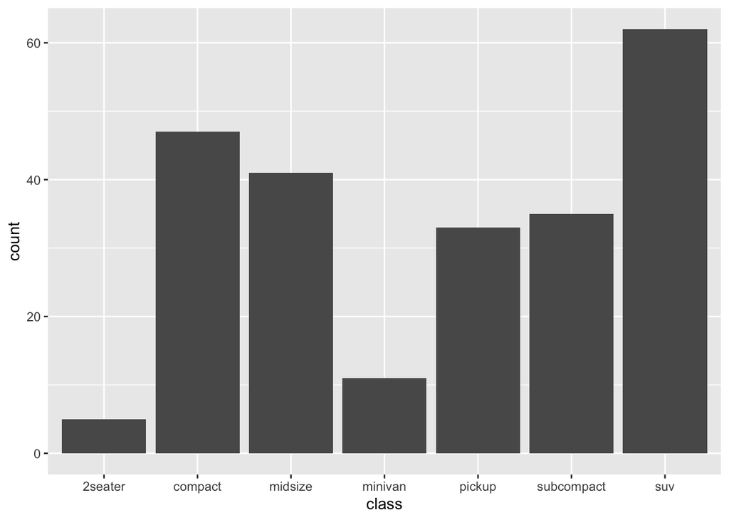

```r
ggplot(mpg) +
  geom_bar(aes(x = class))
```

Solution: The description says “geom_bar() uses stat_count() by default”. Using it directly below:

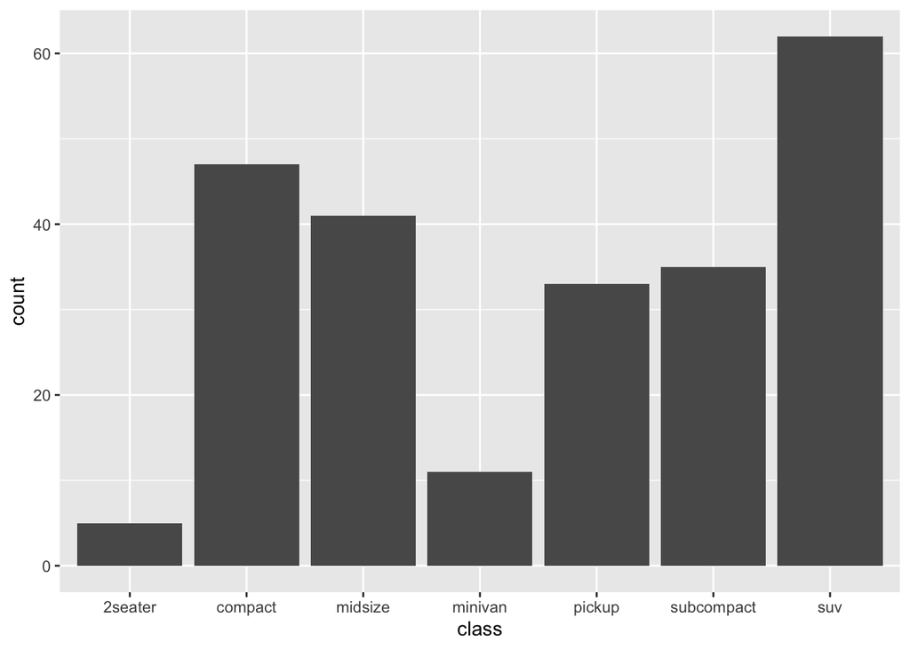

```r
ggplot(mpg) +
  stat_count(aes(x = class))
```

Use `stat_summary()` to add a red dot at the mean `hwy` for each group

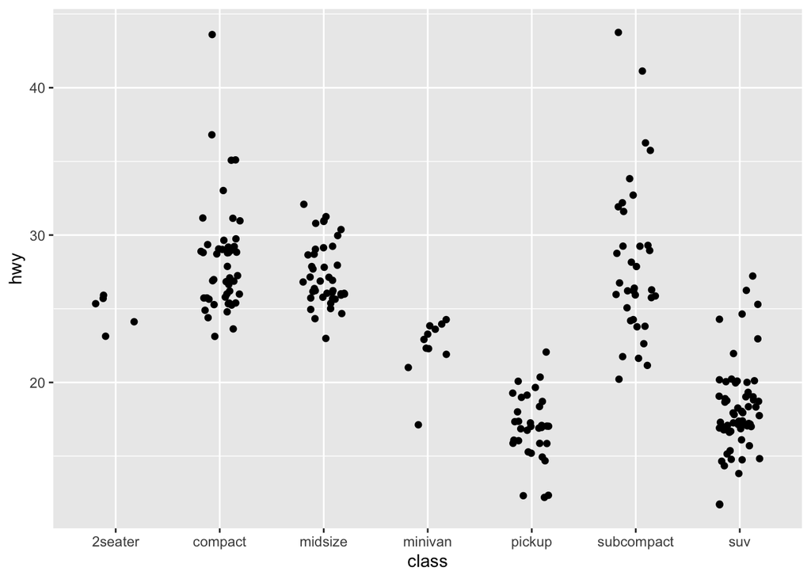

```r
ggplot(mpg) +
  geom_jitter(aes(x = class, y = hwy), width = 0.2)
```

Hint: You will need to change the default geom of `stat_summary()`

Solution:

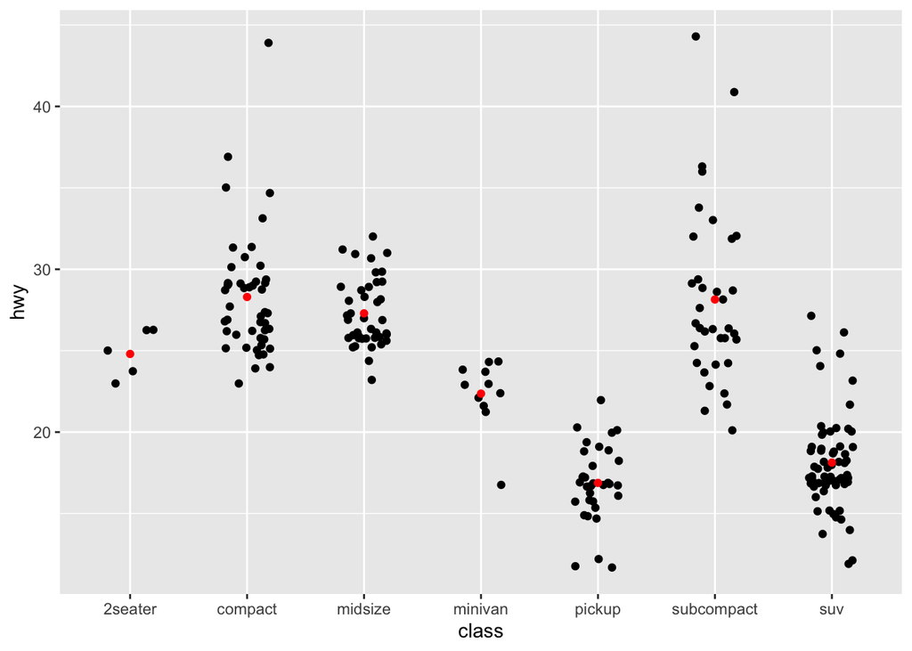

```r
ggplot(mpg, aes(x=class, y=hwy)) +
  geom_jitter(width = 0.2)+
  stat_summary(geom = "point", fun="mean", color="red")
```

In our proportion bar chart, we need to set group = 1. Why? In other words what is the problem with these two graphs?

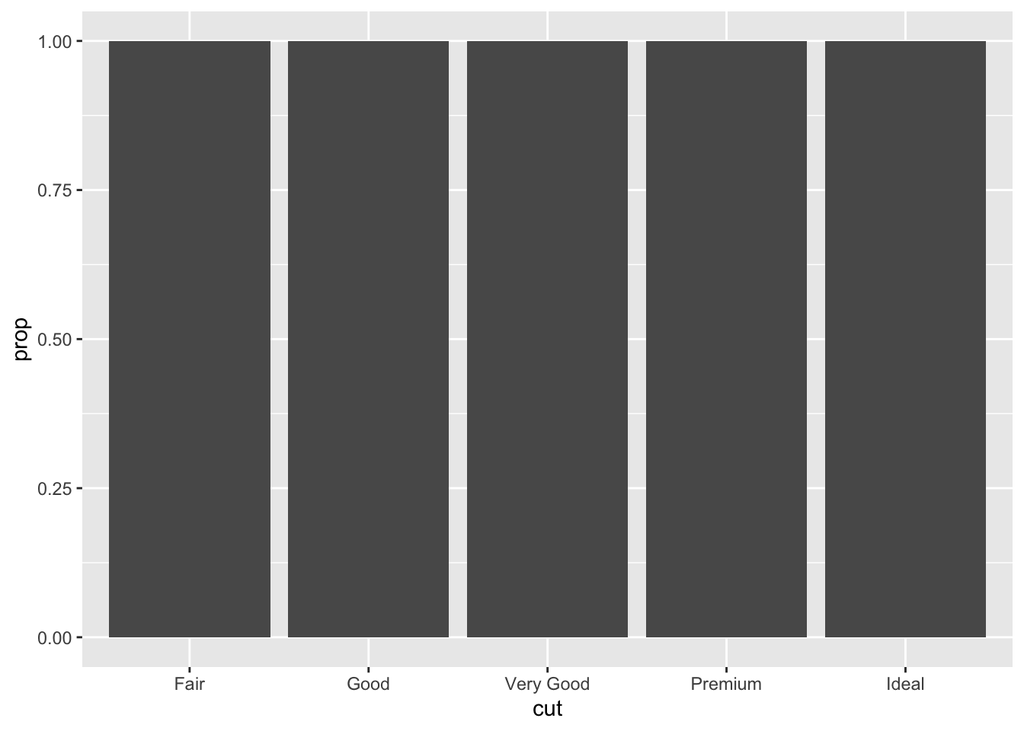

```r
p1<- ggplot(data = diamonds) +
  geom_bar(mapping = aes(x = cut, y = after_stat(prop)))

p2<-ggplot(data = diamonds) +
  geom_bar(mapping = aes(x = cut, fill = color, y = after_stat(prop)))

p1
```

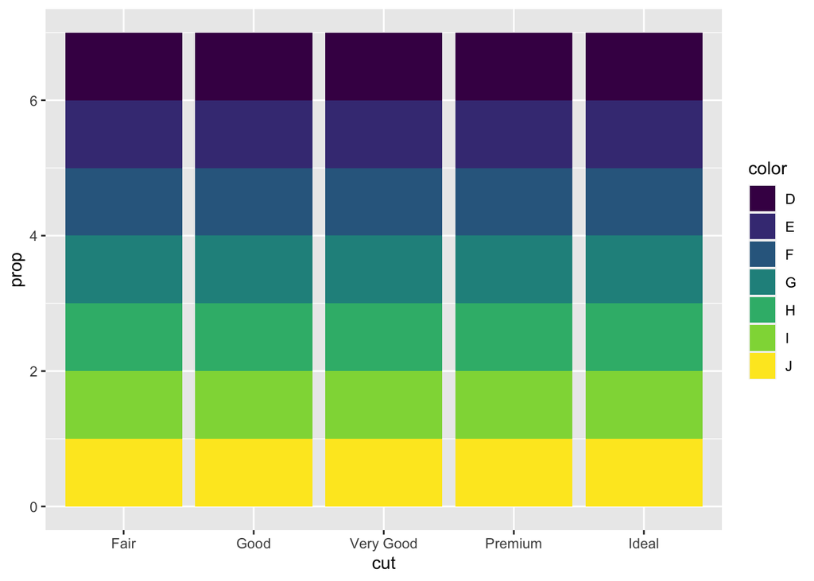

```r
p2
```

Solution: if group = 1 is not included, the proportions will be calculated within each group. Modified code is below.

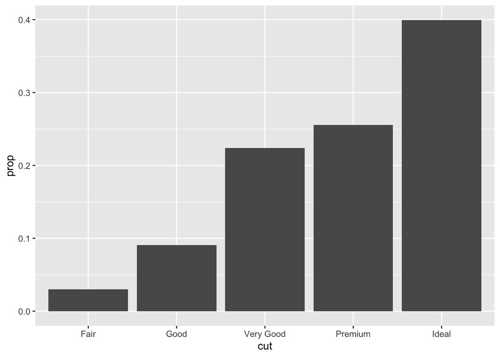

```r
p1_new<- ggplot(data = diamonds) +
  geom_bar(mapping = aes(x = cut, y = after_stat(prop), group=1))

p2_new<-ggplot(data = diamonds) +
  geom_bar(mapping = aes(x = cut, fill = color, y = ..count.. / sum(..count..)))

p1_new
```

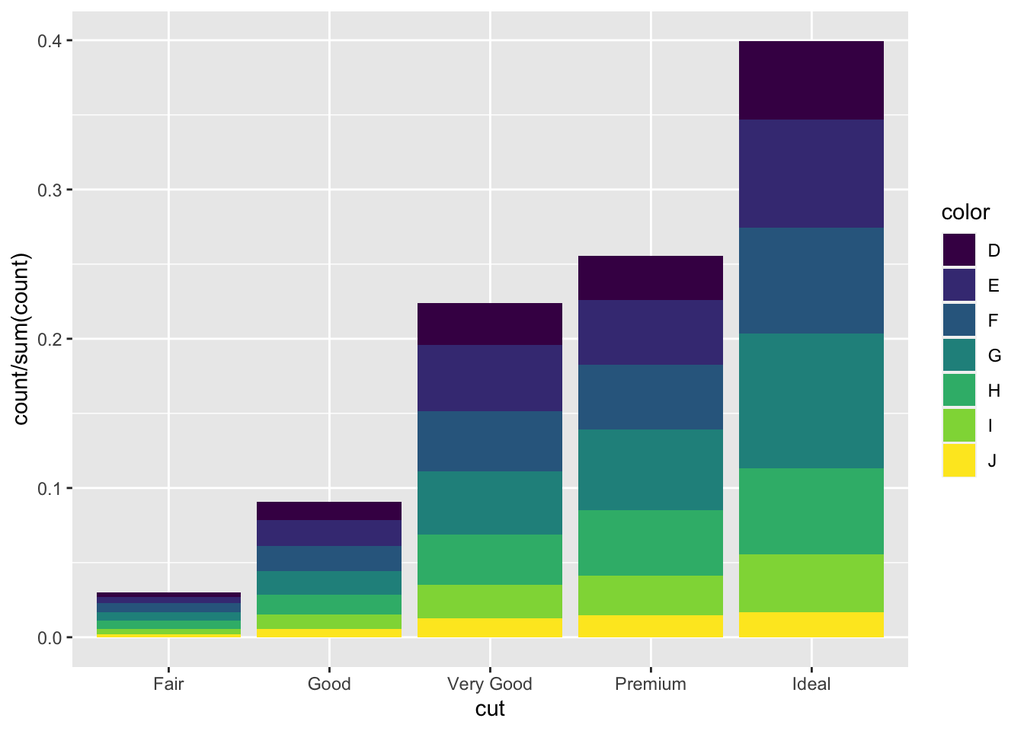

```r
p2_new
```

*** What is the problem with this plot? How could we improve it?

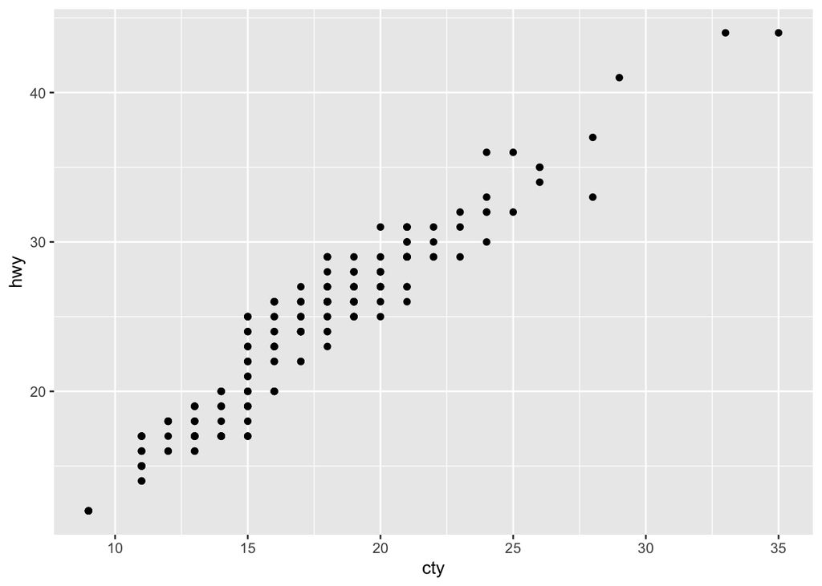

```r
ggplot(data = mpg, mapping = aes(x = cty, y = hwy)) +
  geom_point( )
```

Solution: There is overplotting because there are multiple observations for each combination of `cty` and `hwy` values.

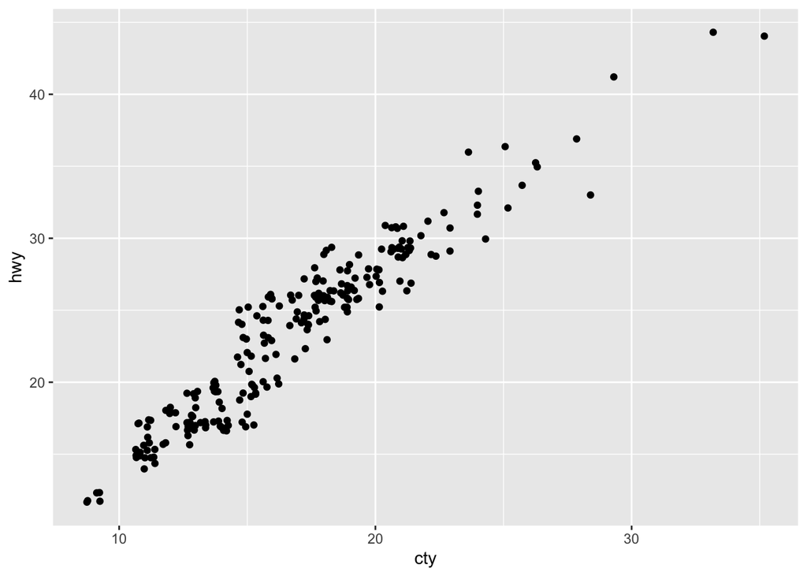

```r
ggplot(data = mpg, mapping = aes(x = cty, y = hwy)) +
  geom_point(position="jitter" )
```

### Scales

#### Exercises

Use `RColorBrewer::display.brewer.all()` to see all the different palettes from Color Brewer and pick your favourite. Modify the code below to use it

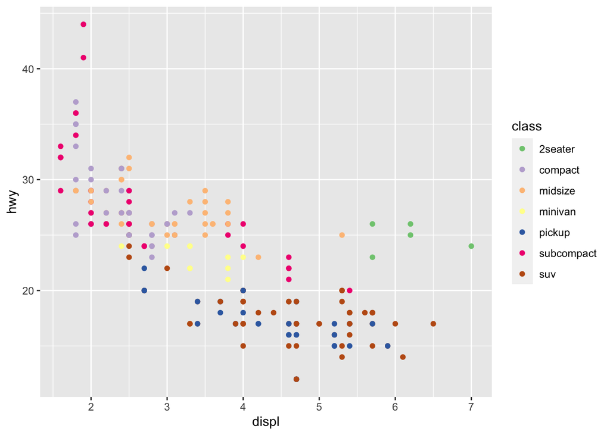

```r
ggplot(mpg) +
  geom_point(aes(x = displ, y = hwy, colour = class)) +
  scale_colour_brewer(type = 'qual')
```

Solution:

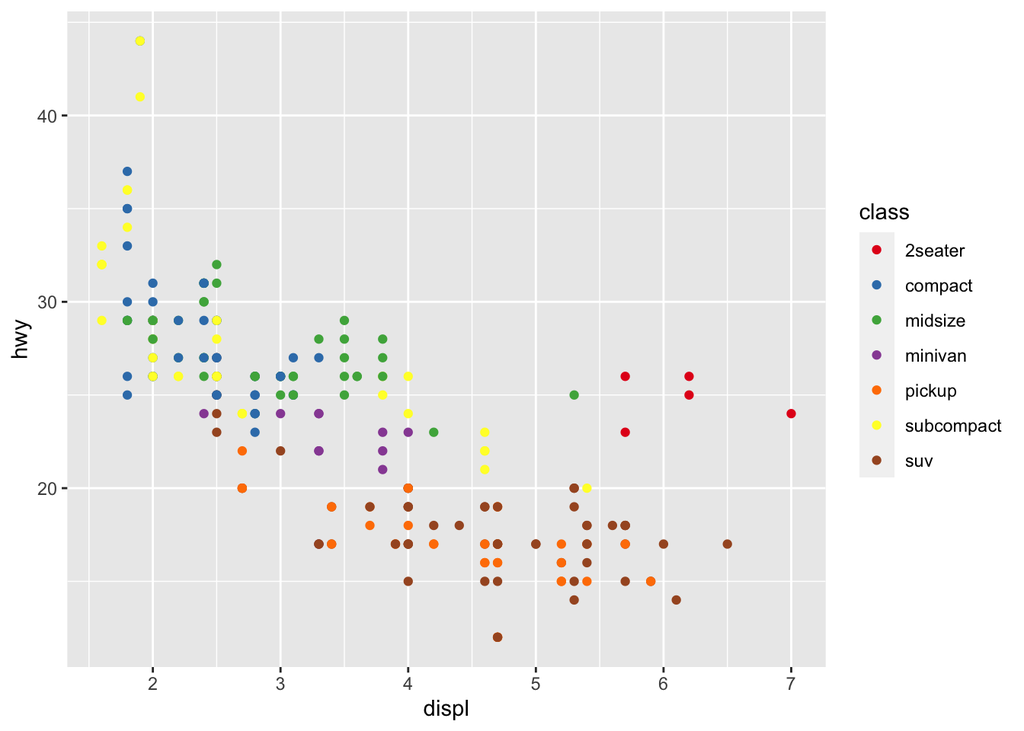

```r
data("mpg")
ggplot(mpg) +
  geom_point(aes(x = displ, y = hwy, colour = class)) +
  scale_colour_brewer(type = 'qual', palette = "Set1")
```

* * *

Modify the code below to create a bubble chart (scatterplot with size mapped to a continuous variable) showing `cyl` with size. Make sure that only the present amount of cylinders (4, 5, 6, and 8) are present in the legend.

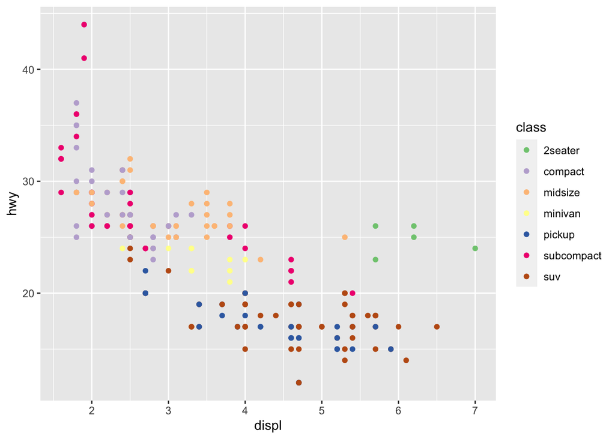

```r
ggplot(mpg) +
  geom_point(aes(x = displ, y = hwy, colour = class)) +
  scale_colour_brewer(type = 'qual')
```

Hint: The `breaks` argument in the scale is used to control which values are present in the legend.

Solution:

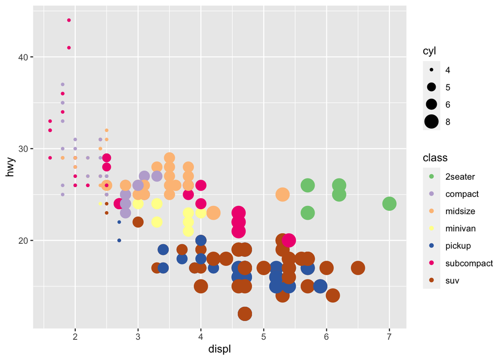

```r
ggplot(mpg) +
  geom_point(aes(x = displ, y = hwy, colour = class, size=cyl)) +
  scale_colour_brewer(type = 'qual') +
  scale_size(breaks = c(4, 5, 6, 8))
```

Explore the different types of size scales available in ggplot2. Is the default the most appropriate here?

Solution: Default is mapping to the radius. But it is not intuitive. Let’s try size mapping by area.

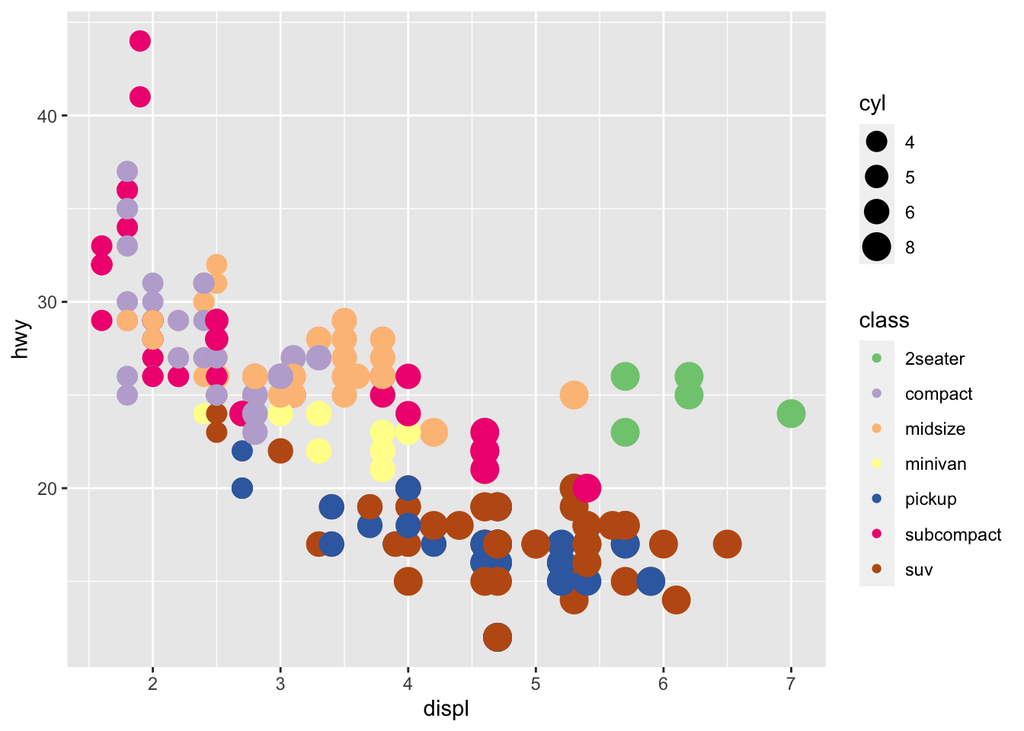

```r
ggplot(mpg) +
  geom_point(aes(x = displ, y = hwy, colour = class, size=cyl)) +
  scale_colour_brewer(type = 'qual') +
  scale_size_area(breaks = c(4, 5, 6, 8))
```

* * *

Modify the code below so that colour is no longer mapped to the discrete `class` variable, but to the continuous `cty` variable. What happens to the guide (legend)?

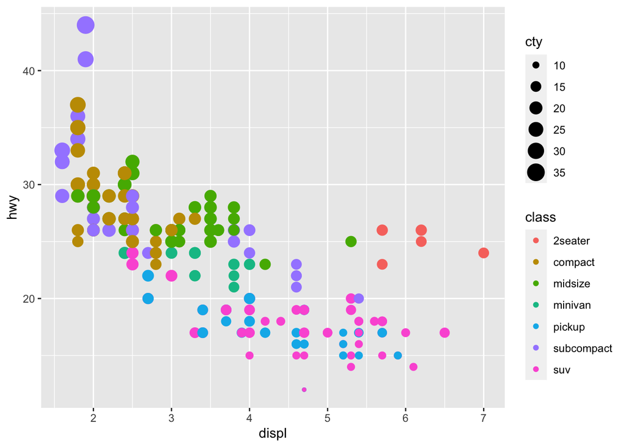

```r
ggplot(mpg) +
  geom_point(aes(x = displ, y = hwy, colour = class, size = cty))
```

Solution:

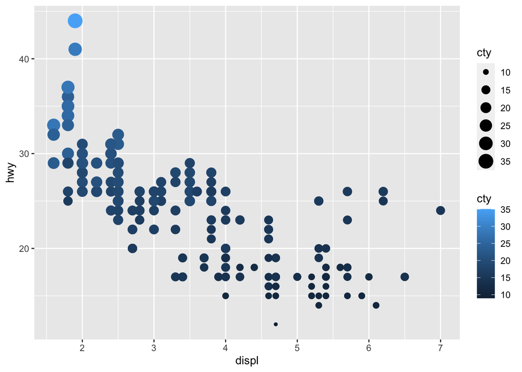

```r
ggplot(mpg) +
  geom_point(aes(x = displ, y = hwy, colour = cty, size = cty))
```

* * *

The type of guide can be controlled with the `guide` argument in the scale, or with the `guides()` function. Continuous colours have a gradient colour bar by default, but setting it to `legend` will turn it back to the standard look. What happens when multiple aesthetics are mapped to the same variable and uses the guide type?

Solution:

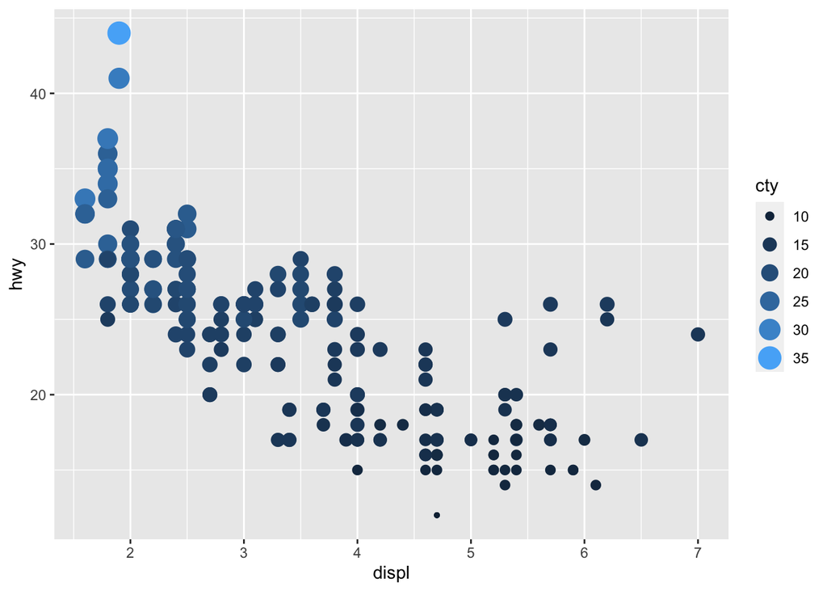

```r
ggplot(mpg) +
  geom_point(aes(x = displ, y = hwy, colour = cty, size = cty))+
  guides(color="legend")
```

ggplot combines both legends.

### Facets

#### Exercises

One of the great things about facets is that they share the axes between the different panels. Sometimes this is undesirable though, and the behavior can be changed with the `scales` argument. Experiment with the different possible settings in the plot below:

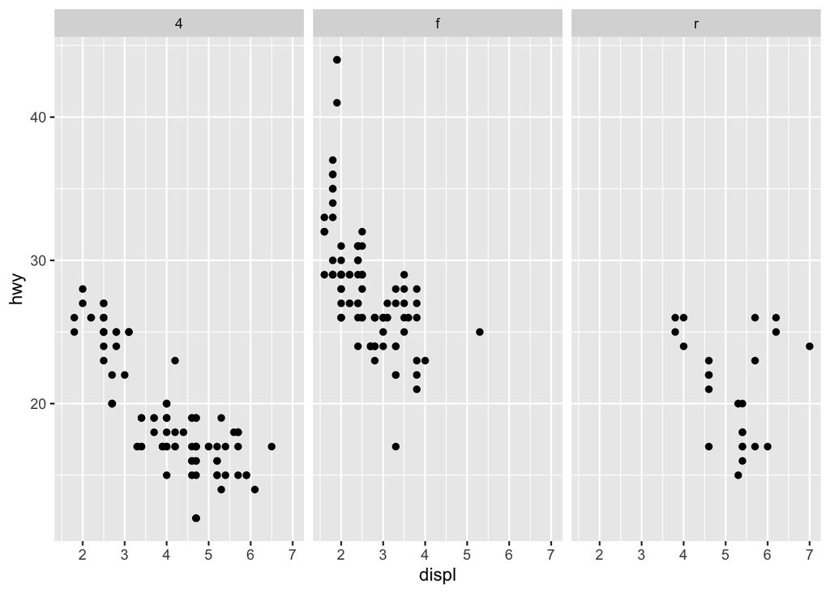

```r
ggplot(mpg) +
  geom_point(aes(x = displ, y = hwy)) +
  facet_wrap(~ drv)
```

Solution:

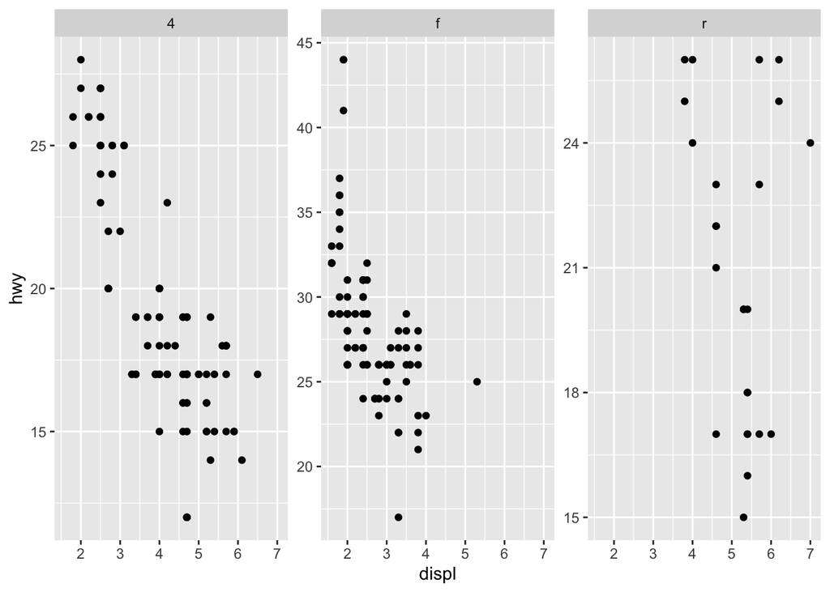

```r
ggplot(mpg) +
  geom_point(aes(x = displ, y = hwy)) +
  facet_wrap(~ drv, scales="free_y")
```

* * *

Usually the space occupied by each panel is equal. This can create problems when different scales are used. Can you modify the code below so that the y scale differs between the panels in the plot. What happens?

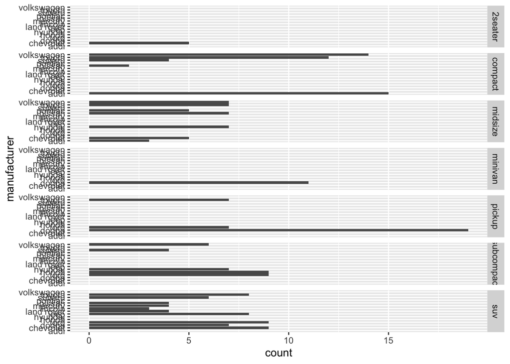

```r
ggplot(mpg) +
  geom_bar(aes(y = manufacturer)) +
  facet_grid(class ~ .)
```

Use the `space` argument in `facet_grid()` to change the plot above so each bar has the same width again.

Solution:

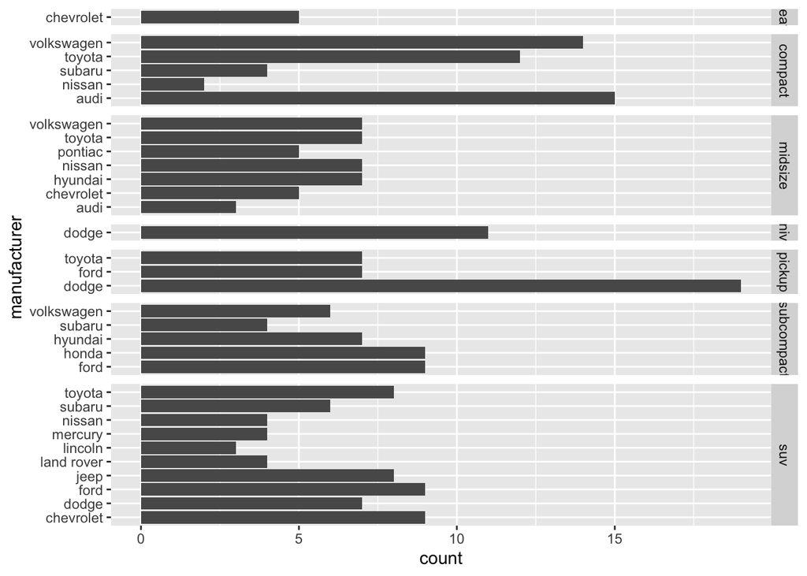

```r
data("mpg")
ggplot(mpg) +
  geom_bar(aes(y = manufacturer)) +
  facet_grid(class ~ ., space = "free_y", scales = "free_y")
```